# The association between prehospital HMGB1 and sepsis in emergency care

Stuthi Iyer

25 April 2022

```r
knitr::opts_chunk$set(fig.retina = 2.5)
knitr::opts_chunk$set(fig.align = "center", message=F, warning=F)

#Load Libraries
library(bookdown)
library(gridExtra)
library(tidyverse)
library(readxl)
library(table1)

#Load Data
my_data1 <- read_excel("~/Downloads/Reduced Data Set 2.xlsx")
```

```r
# Calculating validated clinical illness risk score
my_data1$agescore <- ifelse (my_data1$Care_Age >= 45, 0, 1)
if (my_data1$RespRate<12){
  my_data1$RRscore <- 1
}
if (my_data1$RespRate>12 && my_data1$RespRate<=23){
  my_data1$RRscore <- 0
}
if (my_data1$RespRate>23 && my_data1$RespRate<=35){
  my_data1$RRscore <- 1
}
if (my_data1$RespRate>=36){
  my_data1$RRscore <- 2
}
my_data1$SBPscore <- ifelse (my_data1$SBP <= 90, 1, 0)
my_data1$HRscore <- ifelse (my_data1$HeartRate >= 120, 1, 0)
my_data1$POscore <- ifelse (my_data1$PulseOximetry >= 88, 0, 1)

my_data1$CIRScore <- my_data1$agescore+my_data1$RRscore+my_data1$SBPscore+my_data1$HRscore+my_data1$POscore
```

```r
# Merging Pairs of Data for Wilcoxon Signed-Rank Tests
my_data2 <- data.frame(my_data1$Pair, my_data1$`Experimental Paradigm`, my_data1$Care_Age, my_data1$care_sex, my_data1$elix, my_data1$care_race, my_data1$RespRate, my_data1$SBP, my_data1$PulseOximetry, my_data1$HeartRate, my_data1$CIRScore, my_data1$`hHMGB1 (ng/mL)`, my_data1$ems_lactate_val, my_data1$il6_ems, my_data1$il10_ems, my_data1$tnf_ems, my_data1$Hosp_los, my_data1$ICU, my_data1$Dead)

my_data_case <- my_data2[which(my_data2$my_data1..Experimental.Paradigm.=="Case"),]
my_data_control <- my_data2[which(my_data2$my_data1..Experimental.Paradigm.=="Control"),]

# Fixing names of categories
colnames(my_data_case) <- c("Pair","Experimental Paradigm","Age", "Sex", "Elix", "Race", "RespRate", "SBP", "PulseOx", "HeartRate", "CIRS", "HMGB1", "Lactate", "IL6", "IL10", "TNF", "HospLOS", "ICU", "Dead")
colnames(my_data_case) <- paste(colnames(my_data_case),"case",sep="_")
colnames(my_data_case)[1] <- "Pair"

colnames(my_data_control) <- c("Pair","Experimental Paradigm","Age", "Sex", "Elix", "Race", "RespRate", "SBP", "PulseOx", "HeartRate", "CIRS", "HMGB1", "Lactate", "IL6", "IL10", "TNF", "HospLOS", "ICU", "Dead")
colnames(my_data_control) <- paste(colnames(my_data_control),"control",sep="_")
colnames(my_data_control)[1] <- "Pair"

my_data_final <- merge(my_data_case,my_data_control,by="Pair")
```

# 1 Background

More than 750,000 Americans are hospitalized with sepsis annually, and one in five patients may not survive. Emergency medical services (EMS) provide essential care for more than half of hospitalized sepsis patients, yet the diagnosis of sepsis may be delayed or missed. However, the prehospital interval is a key opportunity for early sepsis recognition, initiation of treatment, and emergency department (ED) notification. Prior prehospital studies developed sepsis recognition models based on subjective data and vital signs with limited success.

Plasma biomarkers provide key information about the presence of acute infection and organ dysfunction in other acute care settings, yet are understudied during prehospital care. One important sepsis biomarker is high mobility group box protein 1 (HMGB1), a ubiquitously expressed nuclear tolerance protein of the damage-associated molecular pattern (DAMP) family. HMGB1 is passively and actively released into circulation as part of early inflammatory response, where it activates innate immune cells. By binding to cell surface receptors, HMGB1 activates endothelial cells, further increasing production of pro-inflammatory cytokines and chemokines. Higher concentrations of HMGB1 are associated with mortality in sepsis, and modulation of HMGB1-mediated responses has been shown to reduce mortality in animal models.

# 2 Methods

EMS clinical data were gathered for each patient encounter from a computerized medical record database (emsCharts, Inc; Warrendale, PA), and linked to electronic health record data at UPMC hospitals (Cerner Powerchart; Cerner, Kansas City, MO). Prehospital vital signs were used to calculate a validated clinical risk score. From the inpatient record, length of stay, rates of intensive care unit (ICU) admission, and in-hospital mortality were determined.

Prehospital blood samples were collected by EMS at the time of prehospital peripheral IV catheter placement and processed by the research team upon ED arrival, as described elsewhere. Plasma samples were frozen at -80°C until assay. Samples were batch analyzed after a single freeze-thaw cycle for interleukin-6 (IL-6), interleukin-10 (IL-10), and tumor necrosis factor (TNF). Plasma levels of HMGB1 were quantified using an HMGB1 express enzyme linked immunosorbent assay (Tecan; Cat. No. 30164033). Blood processing and analysis were completed by the Clinical Research, Investigation, and Systems Modeling of Acute Illness (CRISMA) Clinical Research Biospecimen Core. Demographic and clinical characteristics of patients with and without Sepsis-3 were described. Comparisons between groups were completed with Wilcoxon signed-rank tests for continuous data and Fisher’s exact tests for categorical data. We considered outlier values as two standard deviations above the mean, log transformed HMGB1 values, and reported results as significant at a two-sided p-value of 0.05. R statistical software version 4.1.2 (R Core Team, Vienna, Austria) was employed for statistical analysis.

# 3 Results

## 3.1 HMGB1

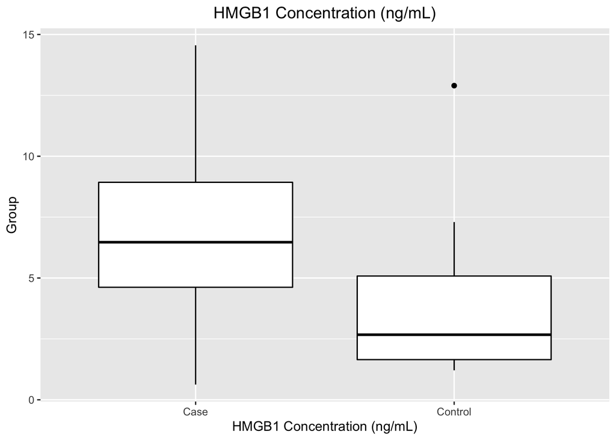

```r
# Boxplot
ggplot(my_data1 %>% drop_na(`hHMGB1 (ng/mL)`, `Experimental Paradigm`), aes(y= `hHMGB1 (ng/mL)`, x=`Experimental Paradigm`)) +
  geom_boxplot(color='black', fill = 'white') +
  ggtitle("HMGB1 Concentration (ng/mL)") +
  theme(plot.title = element_text(hjust = 0.5)) +
  ylab ("Group") +
  xlab ("HMGB1 Concentration (ng/mL)")
```

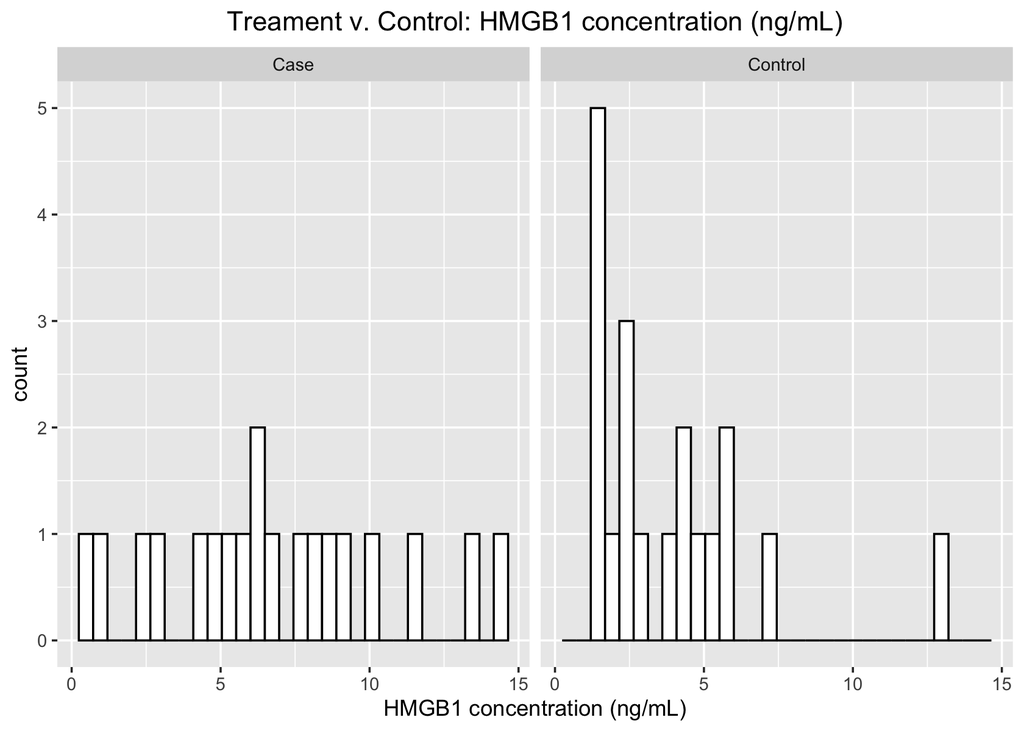

```r
# Histogram
ggplot(my_data1 %>% drop_na(`Experimental Paradigm`, `hHMGB1 (ng/mL)`), aes(x=`hHMGB1 (ng/mL)`)) +
  geom_histogram(color='black', fill ='white') +
  ggtitle("Treament v. Control: HMGB1 concentration (ng/mL)") +
  theme(plot.title = element_text(hjust = 0.5)) +
  xlab ("HMGB1 concentration (ng/mL)") +
  facet_wrap(~`Experimental Paradigm`)
```

```r
# Summary Table
my_data1 %>% group_by(`Experimental Paradigm`) %>%
  summarize(n = n(),
          median = median(`hHMGB1 (ng/mL)`, na.rm=TRUE),
          firstquartile = quantile(`hHMGB1 (ng/mL)`, 0.25, na.rm=TRUE),
          thirdquartile = quantile (`hHMGB1 (ng/mL)`, 0.75, na.rm=TRUE),
          min = min(`hHMGB1 (ng/mL)`, na.rm=TRUE),
          max = max(`hHMGB1 (ng/mL)`, na.rm=TRUE))
```

```
# A tibble: 2 × 7
  `Experimental Paradigm`     n median firstquartile thirdquartile   min   max
  <chr>                   <int>  <dbl>         <dbl>         <dbl> <dbl> <dbl>
1 Case                       19   6.47          4.62          8.93 0.626  14.6
2 Control                    19   2.67          1.65          5.08 1.21   12.9
```

### 3.1.1 Hypothesis Testing Procedure

H0: The population median difference in HMGB1 for cases and controls is equal to zero. H1: The population median difference in HMGB1 for cases and controls is not equal to zero.

The Wilcoxon Signed-Rank Test is used specifically for comparisons of matched pairs and when there are doubts about having normal distributions.

The conditions of this test are that we have simple random samples of our overall patient set and that we have symmetric distributions of our populations of differences, which we will take to be true. That said, we can now run our Wilcoxon Signed-Rank Test.

```r
wilcox.test(my_data_final$HMGB1_case, my_data_final$HMGB1_control, paired=TRUE, correct=FALSE)
```

```
    Wilcoxon signed rank exact test

data:  my_data_final$HMGB1_case and my_data_final$HMGB1_control
V = 173, p-value = 0.0007896
alternative hypothesis: true location shift is not equal to 0
```

We have evidence to suggest that the population median from the case group is not equal to the population median from the control group.

# 4 Table 1

```r
table1(~ Care_Age + care_sex + elix + care_race + RespRate + SBP + PulseOximetry + HeartRate + CIRScore + `hHMGB1 (ng/mL)` + ems_lactate_val + il6_ems + il10_ems + tnf_ems + Hosp_los + ICU + Dead | `Experimental Paradigm`, data = my_data1, overall = T)
```

|  | Case (N=19) | Control (N=19) | TRUE (N=38) |
| --- | --- | --- | --- |
| Care_Age |  |  |  |
| Mean (SD) | 65.2 (15.8) | 60.0 (14.1) | 62.6 (15.0) |
| Median [Min, Max] | 64.0 [21.0, 86.0] | 60.5 [25.0, 90.0] | 63.0 [21.0, 90.0] |
| Missing | 0 (0%) | 1 (5.3%) | 1 (2.6%) |
| care_sex |  |  |  |
| Female | 8 (42.1%) | 8 (42.1%) | 16 (42.1%) |
| Male | 11 (57.9%) | 10 (52.6%) | 21 (55.3%) |
| Unknown | 0 (0%) | 1 (5.3%) | 1 (2.6%) |
| elix |  |  |  |
| Mean (SD) | 0.526 (0.612) | 0.368 (0.597) | 0.447 (0.602) |
| Median [Min, Max] | 0 [0, 2.00] | 0 [0, 2.00] | 0 [0, 2.00] |
| care_race |  |  |  |
| African American | 4 (21.1%) | 4 (21.1%) | 8 (21.1%) |
| White | 15 (78.9%) | 14 (73.7%) | 29 (76.3%) |
| Not Specified | 0 (0%) | 1 (5.3%) | 1 (2.6%) |
| RespRate |  |  |  |
| Mean (SD) | 20.2 (6.70) | 18.8 (3.96) | 19.5 (5.40) |
| Median [Min, Max] | 18.0 [14.0, 36.0] | 18.0 [14.0, 32.0] | 18.0 [14.0, 36.0] |
| Missing | 2 (10.5%) | 0 (0%) | 2 (5.3%) |
| SBP |  |  |  |
| Mean (SD) | 127 (28.3) | 157 (32.5) | 143 (33.8) |
| Median [Min, Max] | 128 [80.0, 172] | 152 [100, 244] | 143 [80.0, 244] |
| Missing | 2 (10.5%) | 0 (0%) | 2 (5.3%) |
| PulseOximetry |  |  |  |
| Mean (SD) | 95.8 (4.28) | 97.5 (2.06) | 96.7 (3.36) |
| Median [Min, Max] | 98.0 [88.0, 100] | 98.0 [93.0, 100] | 98.0 [88.0, 100] |
| Missing | 2 (10.5%) | 0 (0%) | 2 (5.3%) |
| HeartRate |  |  |  |
| Mean (SD) | 89.5 (17.5) | 99.5 (23.4) | 94.8 (21.1) |
| Median [Min, Max] | 88.0 [60.0, 124] | 98.0 [72.0, 170] | 93.0 [60.0, 170] |
| Missing | 2 (10.5%) | 0 (0%) | 2 (5.3%) |
| CIRScore |  |  |  |
| Mean (SD) | 0.235 (0.437) | 0.222 (0.428) | 0.229 (0.426) |
| Median [Min, Max] | 0 [0, 1.00] | 0 [0, 1.00] | 0 [0, 1.00] |
| Missing | 2 (10.5%) | 1 (5.3%) | 3 (7.9%) |
| hHMGB1 (ng/mL) |  |  |  |
| Mean (SD) | 6.80 (3.85) | 3.84 (2.88) | 5.32 (3.67) |
| Median [Min, Max] | 6.47 [0.626, 14.6] | 2.67 [1.21, 12.9] | 4.81 [0.626, 14.6] |
| ems_lactate_val |  |  |  |
| Mean (SD) | 2.29 (1.80) | 2.31 (1.51) | 2.30 (1.62) |
| Median [Min, Max] | 1.60 [0, 7.20] | 2.00 [0, 6.50] | 1.85 [0, 7.20] |
| Missing | 4 (21.1%) | 2 (10.5%) | 6 (15.8%) |
| il6_ems |  |  |  |
| Mean (SD) | 441 (697) | 56.3 (110) | 249 (529) |
| Median [Min, Max] | 63.3 [4.57, 2320] | 11.7 [3.34, 421] | 20.4 [3.34, 2320] |
| Missing | 2 (10.5%) | 2 (10.5%) | 4 (10.5%) |
| il10_ems |  |  |  |
| Mean (SD) | 37.1 (102) | 89.0 (266) | 63.0 (200) |
| Median [Min, Max] | 4.75 [1.57, 414] | 2.69 [1.26, 1040] | 3.00 [1.26, 1040] |
| Missing | 2 (10.5%) | 2 (10.5%) | 4 (10.5%) |
| tnf_ems |  |  |  |
| Mean (SD) | 424 (1580) | 12.6 (15.8) | 218 (1120) |
| Median [Min, Max] | 6.87 [4.87, 6520] | 6.87 [4.87, 61.0] | 6.87 [4.87, 6520] |
| Missing | 2 (10.5%) | 2 (10.5%) | 4 (10.5%) |
| Hosp_los |  |  |  |
| Mean (SD) | 6.37 (4.86) | 1.79 (1.13) | 4.08 (4.18) |
| Median [Min, Max] | 5.00 [2.00, 19.0] | 1.00 [1.00, 5.00] | 2.50 [1.00, 19.0] |
| ICU |  |  |  |
| No | 15 (78.9%) | 19 (100%) | 34 (89.5%) |
| Yes | 4 (21.1%) | 0 (0%) | 4 (10.5%) |
| Dead |  |  |  |
| No | 17 (89.5%) | 19 (100%) | 36 (94.7%) |
| Yes | 2 (10.5%) | 0 (0%) | 2 (5.3%) |

## 4.1 Statistical Testing based on Distributions

### 4.1.1 Features

#### 4.1.1.1 Age

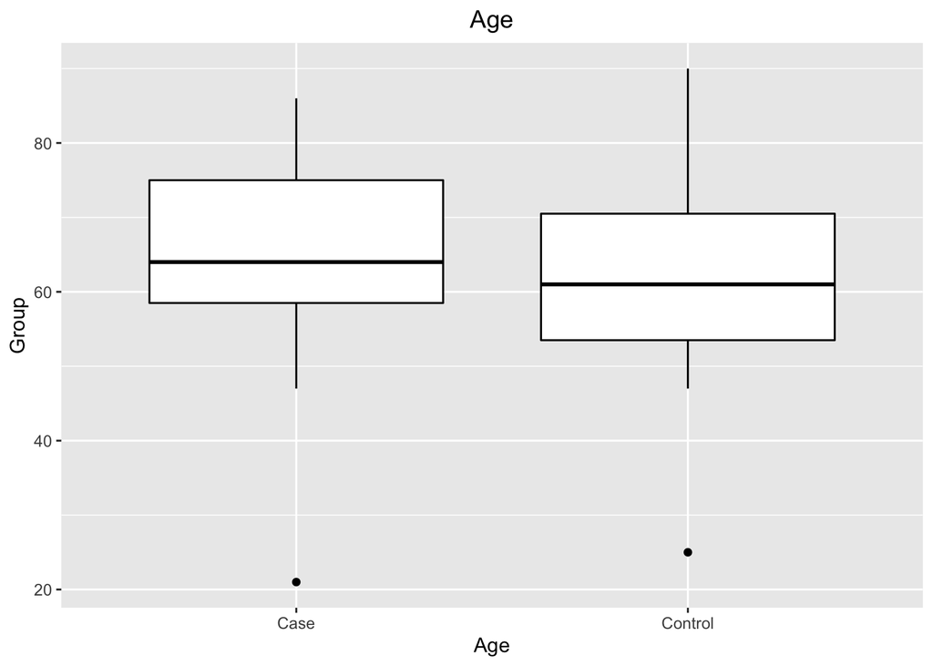

```r
ggplot(my_data1 %>% drop_na(`hHMGB1 (ng/mL)`, `Experimental Paradigm`), aes(y= Age, x=`Experimental Paradigm`)) +
  geom_boxplot(color='black', fill = 'white') +
  ggtitle("Age") +
  theme(plot.title = element_text(hjust = 0.5)) +
  ylab ("Group") +
  xlab ("Age")
```

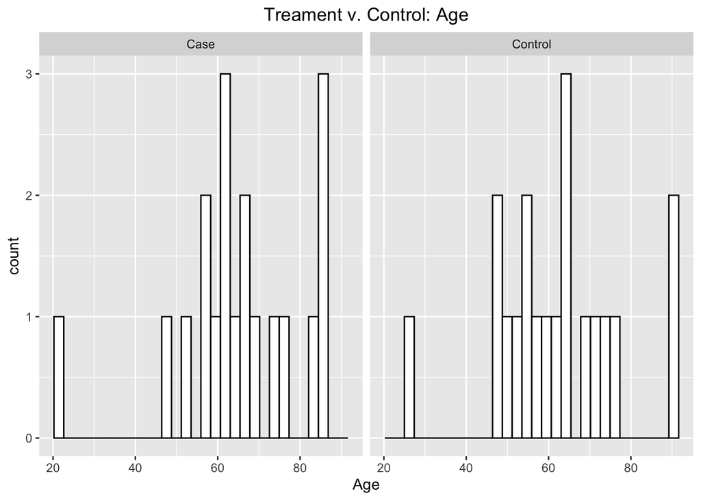

```r
ggplot(my_data1 %>% drop_na(`Experimental Paradigm`, Age), aes(x=Age)) +
  geom_histogram(color='black', fill ='white') +
  ggtitle("Treament v. Control: Age") +
  theme(plot.title = element_text(hjust = 0.5)) +
  xlab ("Age") +
  facet_wrap(~`Experimental Paradigm`)
```

Left skewed, so will use a Wilcoxon signed-rank.

```r
wilcox.test(my_data_final$Age_case, my_data_final$Age_control, paired=TRUE, correct=FALSE)
```

[output not shown]

#### 4.1.1.2 Sex

```r
table(my_data1$`Experimental Paradigm`,my_data1$care_sex)
```

```
          Female Male Unknown
  Case         8   11       0
  Control      8   10       1
```

```r
m <- matrix(c(8, 8, 11, 10), nrow = 2)
fisher.test(m)
```

```
    Fisher's Exact Test for Count Data

data:  m
p-value = 1
alternative hypothesis: true odds ratio is not equal to 1
95 percent confidence interval:
 0.2047873 4.0341323
sample estimates:
odds ratio
 0.9114378
```

#### 4.1.1.3 Elix

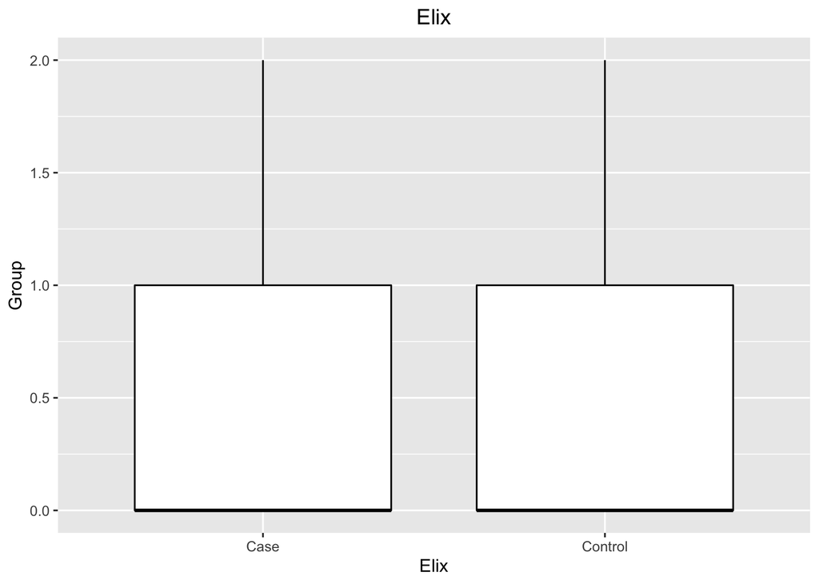

```r
ggplot(my_data1 %>% drop_na(elix, `Experimental Paradigm`), aes(y= elix, x=`Experimental Paradigm`)) +
  geom_boxplot(color='black', fill = 'white') +
  ggtitle("Elix") +
  theme(plot.title = element_text(hjust = 0.5)) +
  ylab ("Group") +
  xlab ("Elix")
```

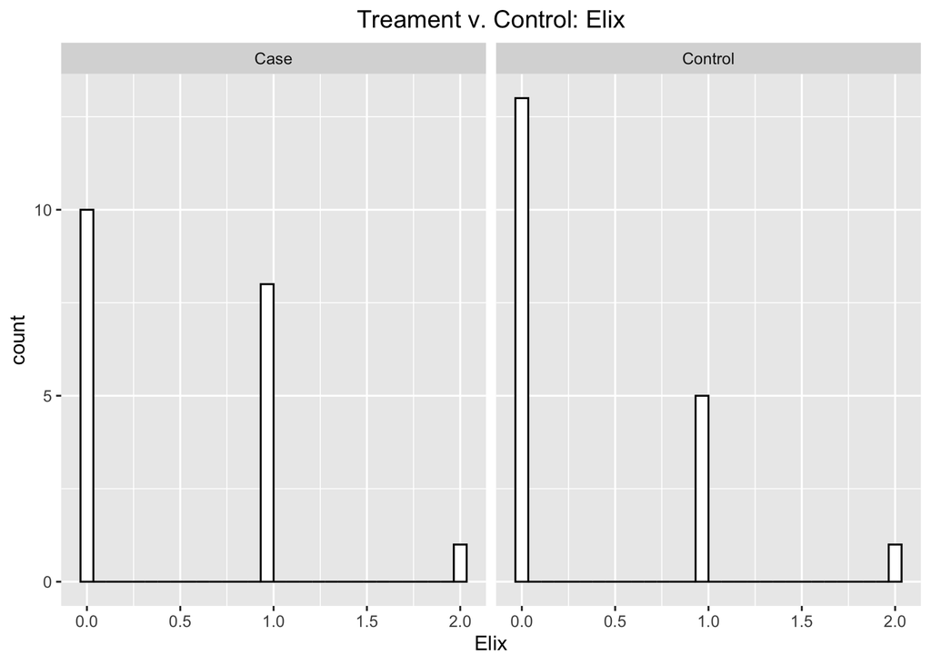

```r
ggplot(my_data1 %>% drop_na(`Experimental Paradigm`, elix), aes(x=elix)) +
  geom_histogram(color='black', fill ='white') +
  ggtitle("Treament v. Control: Elix") +
  theme(plot.title = element_text(hjust = 0.5)) +
  xlab ("Elix") +
  facet_wrap(~`Experimental Paradigm`)
```

Right skewed, so will use a Wilcoxon signed-rank.

```r
wilcox.test(my_data_final$Elix_case, my_data_final$Elix_control, paired=TRUE, correct=FALSE)
```

```
    Wilcoxon signed rank test

data:  my_data_final$Elix_case and my_data_final$Elix_control
V = 6, p-value = 0.08326
alternative hypothesis: true location shift is not equal to 0
```

#### 4.1.1.4 Race

```r
table(my_data1$`Experimental Paradigm`,my_data1$care_race)
```

```
          African American Not Specified White
  Case                   4             0    15
  Control                4             1    14
```

```r
m <- matrix(c(4, 4, 0, 1, 15, 14), nrow = 2)
fisher.test(m)
```

```
    Fisher's Exact Test for Count Data

data:  m
p-value = 1
alternative hypothesis: two.sided
```

### 4.1.2 Prehospital Assessment

#### 4.1.2.1 Resp Rate

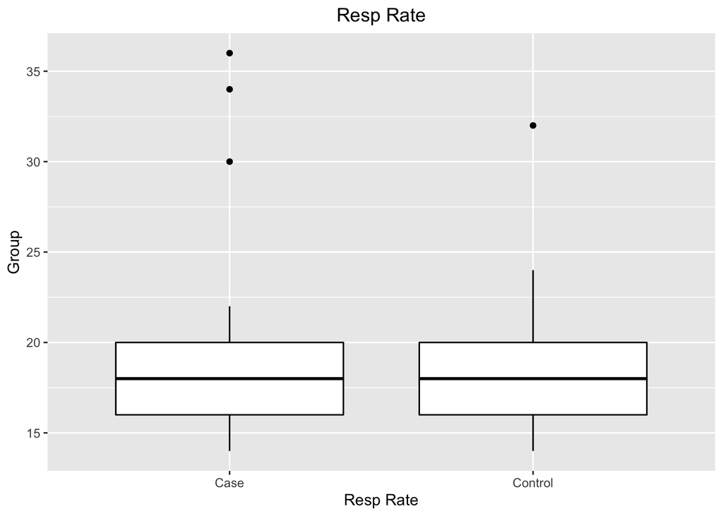

```r
ggplot(my_data1 %>% drop_na(RespRate, `Experimental Paradigm`), aes(y= RespRate, x=`Experimental Paradigm`)) +
  geom_boxplot(color='black', fill = 'white') +
  ggtitle("Resp Rate") +
  theme(plot.title = element_text(hjust = 0.5)) +
  ylab ("Group") +
  xlab ("Resp Rate")
```

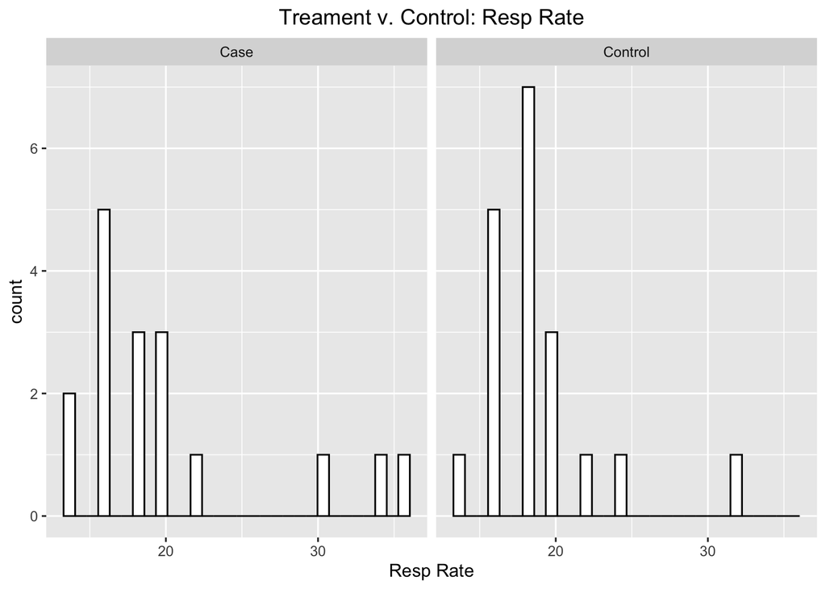

```r
ggplot(my_data1 %>% drop_na(`Experimental Paradigm`, RespRate), aes(x=RespRate)) +
  geom_histogram(color='black', fill ='white') +
  ggtitle("Treament v. Control: Resp Rate") +
  theme(plot.title = element_text(hjust = 0.5)) +
  xlab ("Resp Rate") +
  facet_wrap(~`Experimental Paradigm`)
```

Right skewed, so will use a Wilcoxon signed-rank.

```r
wilcox.test(my_data_final$RespRate_case, my_data_final$RespRate_control, paired=TRUE, correct=FALSE)
```

```
    Wilcoxon signed rank test

data:  my_data_final$RespRate_case and my_data_final$RespRate_control
V = 55, p-value = 0.8735
alternative hypothesis: true location shift is not equal to 0
```

#### 4.1.2.2 PulseOximetry

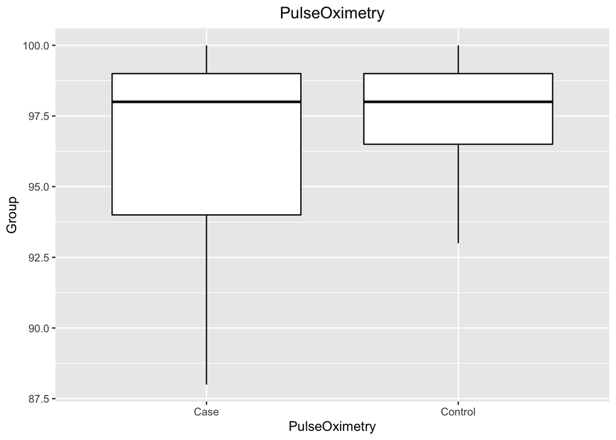

```r
ggplot(my_data1 %>% drop_na(PulseOximetry, `Experimental Paradigm`), aes(y= PulseOximetry, x=`Experimental Paradigm`)) +
  geom_boxplot(color='black', fill = 'white') +
  ggtitle("PulseOximetry") +
  theme(plot.title = element_text(hjust = 0.5)) +
  ylab ("Group") +
  xlab ("PulseOximetry")
```

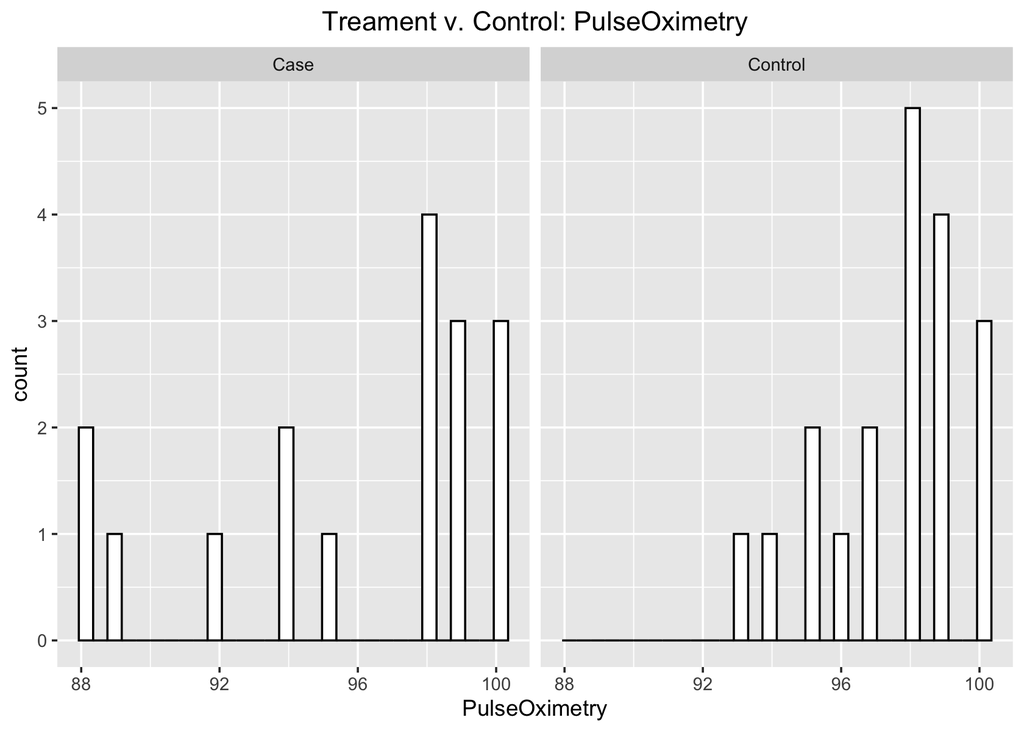

```r
ggplot(my_data1 %>% drop_na(`Experimental Paradigm`, PulseOximetry), aes(x=PulseOximetry)) +
  geom_histogram(color='black', fill ='white') +
  ggtitle("Treament v. Control: PulseOximetry") +
  theme(plot.title = element_text(hjust = 0.5)) +
  xlab ("PulseOximetry") +
  facet_wrap(~`Experimental Paradigm`)
```

Left skewed, so will use a Wilcoxon signed-rank.

```r
wilcox.test(my_data_final$PulseOx_case, my_data_final$PulseOx_control, paired=TRUE, correct=FALSE)
```

```
    Wilcoxon signed rank test

data:  my_data_final$PulseOx_case and my_data_final$PulseOx_control
V = 22, p-value = 0.09897
alternative hypothesis: true location shift is not equal to 0
```

#### 4.1.2.3 SBP

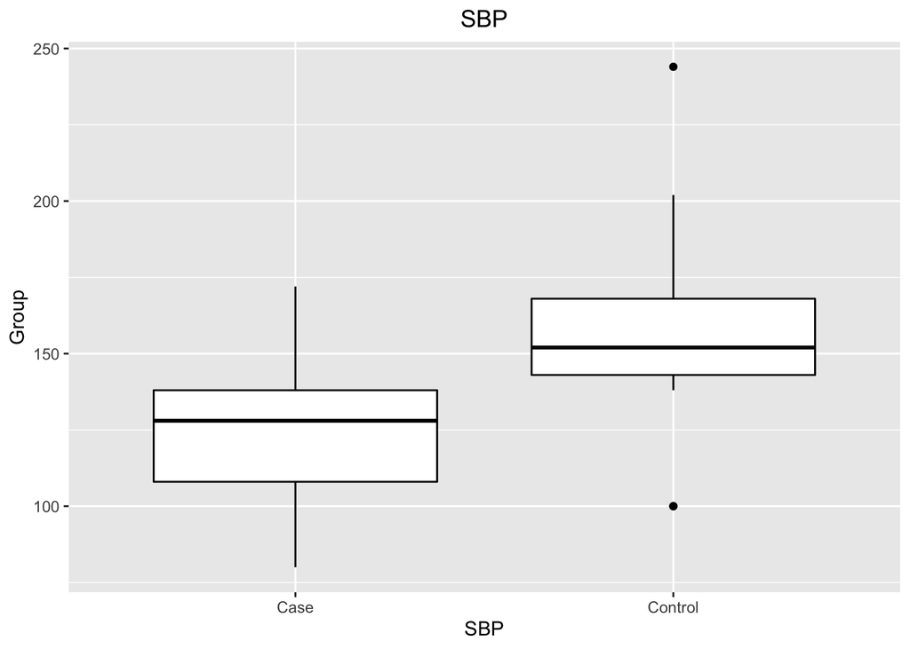

```r
ggplot(my_data1 %>% drop_na(SBP, `Experimental Paradigm`), aes(y= SBP, x=`Experimental Paradigm`)) +
  geom_boxplot(color='black', fill = 'white') +
  ggtitle("SBP") +
  theme(plot.title = element_text(hjust = 0.5)) +
  ylab ("Group") +
  xlab ("SBP")
```

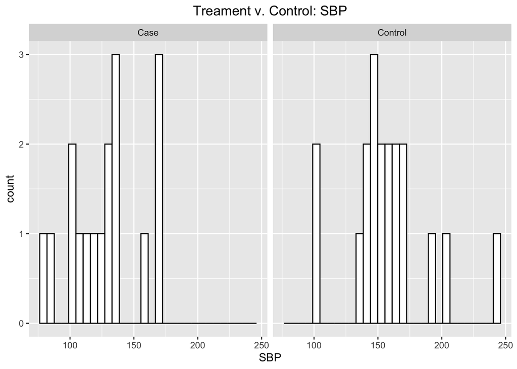

```r
ggplot(my_data1 %>% drop_na(`Experimental Paradigm`, SBP), aes(x=SBP)) +
  geom_histogram(color='black', fill ='white') +
  ggtitle("Treament v. Control: SBP") +
  theme(plot.title = element_text(hjust = 0.5)) +
  xlab ("SBP") +
  facet_wrap(~`Experimental Paradigm`)
```

Left-skewed case data, so will use a Wilcoxon signed-rank.

```r
wilcox.test(my_data_final$SBP_case, my_data_final$SBP_control, paired=TRUE, correct=FALSE)
```

```
    Wilcoxon signed rank test

data:  my_data_final$SBP_case and my_data_final$SBP_control
V = 26, p-value = 0.02987
alternative hypothesis: true location shift is not equal to 0
```

#### 4.1.2.4 Heart Rate

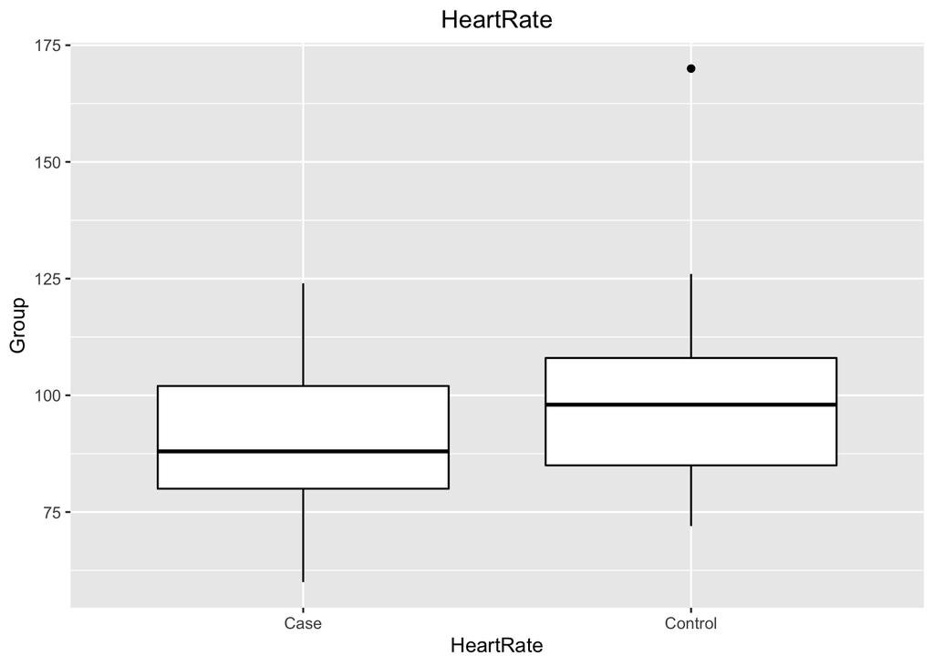

```r
ggplot(my_data1 %>% drop_na(HeartRate, `Experimental Paradigm`), aes(y= HeartRate, x=`Experimental Paradigm`)) +
  geom_boxplot(color='black', fill = 'white') +
  ggtitle("HeartRate") +
  theme(plot.title = element_text(hjust = 0.5)) +
  ylab ("Group") +
  xlab ("HeartRate")
```

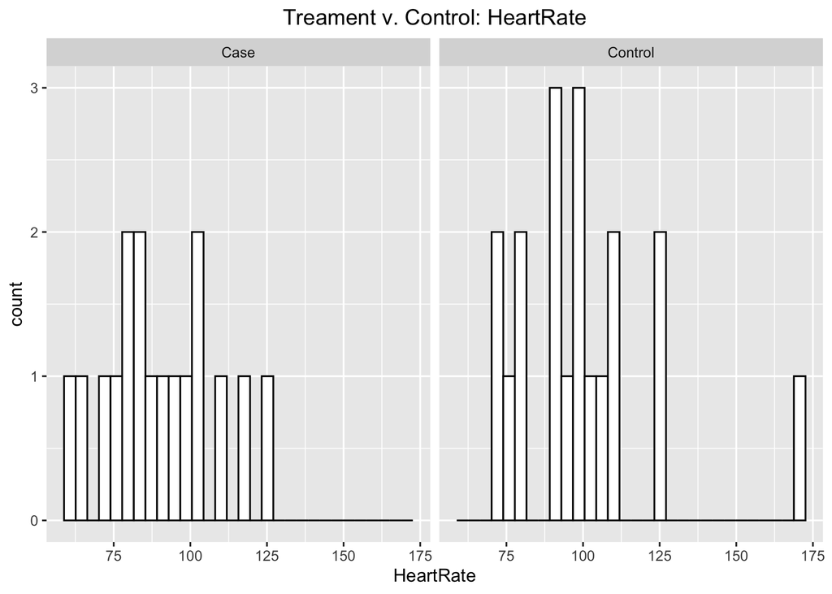

```r
ggplot(my_data1 %>% drop_na(`Experimental Paradigm`, HeartRate), aes(x=HeartRate)) +
  geom_histogram(color='black', fill ='white') +
  ggtitle("Treament v. Control: HeartRate") +
  theme(plot.title = element_text(hjust = 0.5)) +
  xlab ("HeartRate") +
  facet_wrap(~`Experimental Paradigm`)
```

Control data set is right-skewed, so will use a Wilcoxon signed-rank.

```r
wilcox.test(my_data_final$HeartRate_case, my_data_final$HeartRate_control, paired=TRUE, correct=FALSE)
```

```
    Wilcoxon signed rank test

data:  my_data_final$HeartRate_case and my_data_final$HeartRate_control
V = 35.5, p-value = 0.09263
alternative hypothesis: true location shift is not equal to 0
```

#### 4.1.2.5 Critical Illness Risk Score

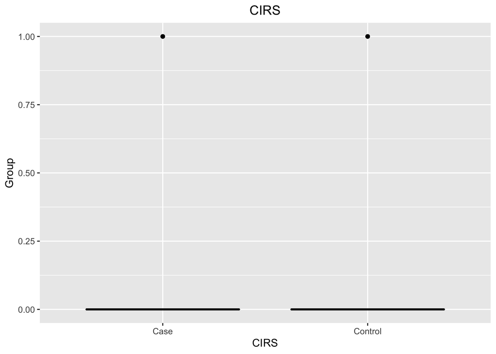

```r
ggplot(my_data1 %>% drop_na(CIRScore, `Experimental Paradigm`), aes(y= CIRScore, x=`Experimental Paradigm`)) +
  geom_boxplot(color='black', fill = 'white') +
  ggtitle("CIRS") +
  theme(plot.title = element_text(hjust = 0.5)) +
  ylab ("Group") +
  xlab ("CIRS")
```

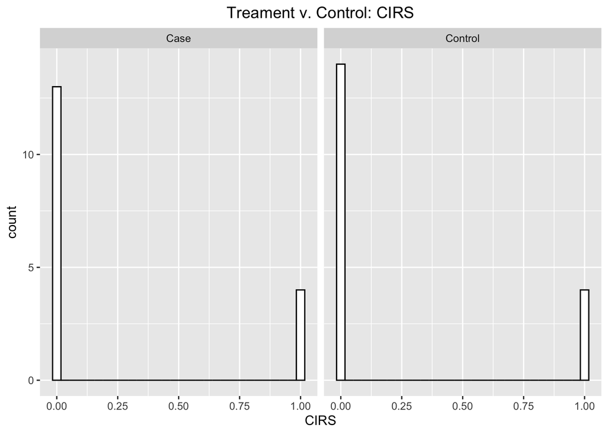

```r
ggplot(my_data1 %>% drop_na(`Experimental Paradigm`, CIRScore), aes(x=CIRScore)) +
  geom_histogram(color='black', fill ='white') +
  ggtitle("Treament v. Control: CIRS") +
  theme(plot.title = element_text(hjust = 0.5)) +
  xlab ("CIRS") +
  facet_wrap(~`Experimental Paradigm`)
```

Right-skewed, so will use a Wilcoxon signed-rank.

```r
wilcox.test(my_data_final$CIRS_case, my_data_final$CIRS_control, paired=TRUE, correct=FALSE)
```

```
    Wilcoxon signed rank test

data:  my_data_final$CIRS_case and my_data_final$CIRS_control
V = 9, p-value = 0.6547
alternative hypothesis: true location shift is not equal to 0
```

### 4.1.3 Prehospital Biomarkers

#### 4.1.3.1 Lactate

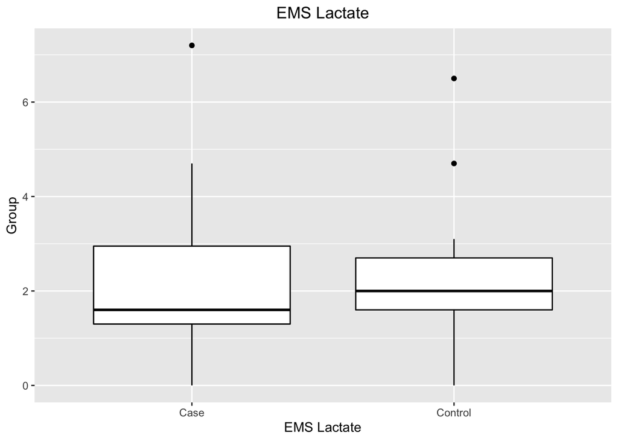

```r
ggplot(my_data1 %>% drop_na(ems_lactate_val, `Experimental Paradigm`), aes(y= ems_lactate_val, x=`Experimental Paradigm`)) +
  geom_boxplot(color='black', fill = 'white') +
  ggtitle("EMS Lactate") +
  theme(plot.title = element_text(hjust = 0.5)) +
  ylab ("Group") +
  xlab ("EMS Lactate")
```

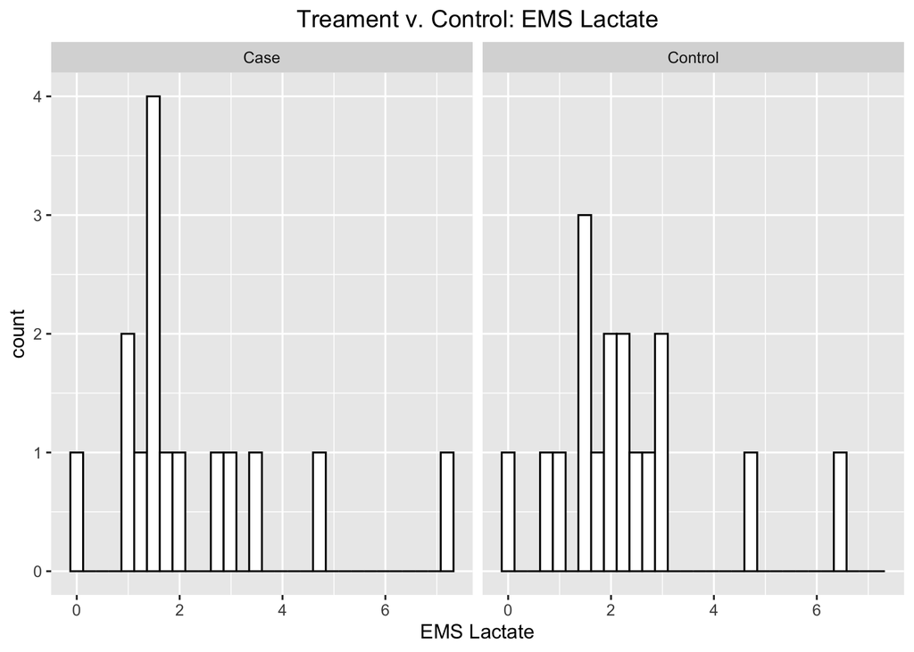

```r
ggplot(my_data1 %>% drop_na(`Experimental Paradigm`, ems_lactate_val), aes(x=ems_lactate_val)) +
  geom_histogram(color='black', fill ='white') +
  ggtitle("Treament v. Control: EMS Lactate") +
  theme(plot.title = element_text(hjust = 0.5)) +
  xlab ("EMS Lactate") +
  facet_wrap(~`Experimental Paradigm`)
```

Case data set is right-skewed, so will use a Wilcoxon signed-rank.

```r
wilcox.test(my_data_final$Lactate_case, my_data_final$Lactate_control, paired=TRUE, correct=FALSE)
```

```
    Wilcoxon signed rank test

data:  my_data_final$Lactate_case and my_data_final$Lactate_control
V = 36.5, p-value = 0.5292
alternative hypothesis: true location shift is not equal to 0
```

#### 4.1.3.2 IL-6

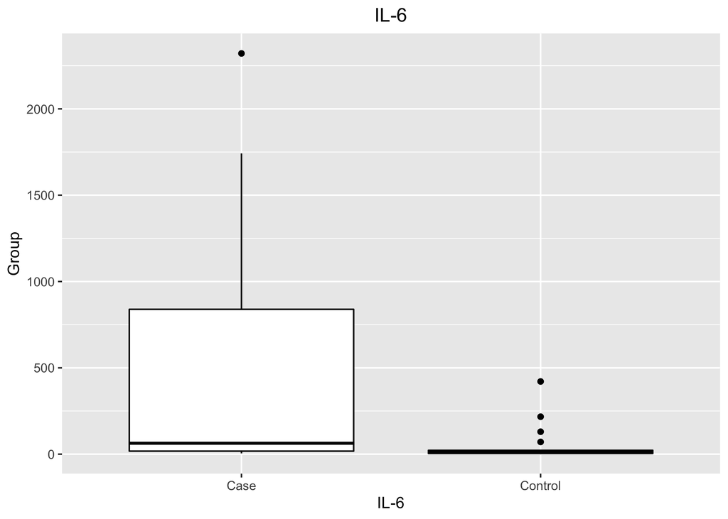

```r
ggplot(my_data1 %>% drop_na(il6_ems, `Experimental Paradigm`), aes(y= il6_ems, x=`Experimental Paradigm`)) +
  geom_boxplot(color='black', fill = 'white') +
  ggtitle("IL-6") +
  theme(plot.title = element_text(hjust = 0.5)) +
  ylab ("Group") +
  xlab ("IL-6")
```

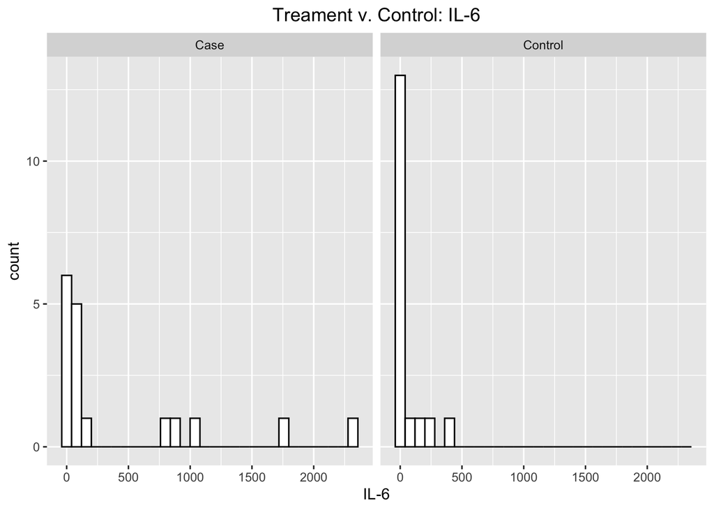

```r
ggplot(my_data1 %>% drop_na(`Experimental Paradigm`, il6_ems), aes(x=il6_ems)) +
  geom_histogram(color='black', fill ='white') +
  ggtitle("Treament v. Control: IL-6") +
  theme(plot.title = element_text(hjust = 0.5)) +
  xlab ("IL-6") +
  facet_wrap(~`Experimental Paradigm`)
```

Right-skewed, so will use a Wilcoxon signed-rank.

```r
wilcox.test(my_data_final$IL6_case, my_data_final$IL6_control, paired=TRUE, correct=FALSE)
```

```
    Wilcoxon signed rank exact test

data:  my_data_final$IL6_case and my_data_final$IL6_control
V = 103, p-value = 0.07391
alternative hypothesis: true location shift is not equal to 0
```

#### 4.1.3.3 IL-10

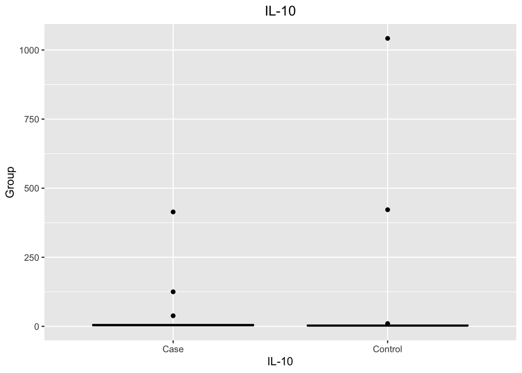

```r
ggplot(my_data1 %>% drop_na(il10_ems, `Experimental Paradigm`), aes(y= il10_ems, x=`Experimental Paradigm`)) +
  geom_boxplot(color='black', fill = 'white') +
  ggtitle("IL-10") +
  theme(plot.title = element_text(hjust = 0.5)) +
  ylab ("Group") +
  xlab ("IL-10")
```

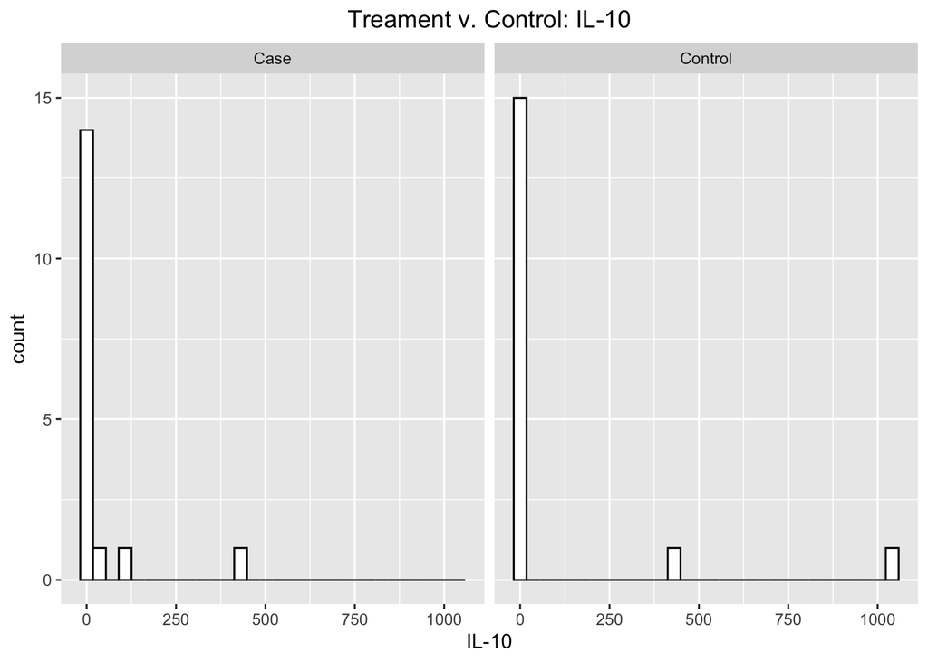

```r
ggplot(my_data1 %>% drop_na(`Experimental Paradigm`, il10_ems), aes(x=il10_ems)) +
  geom_histogram(color='black', fill ='white') +
  ggtitle("Treament v. Control: IL-10") +
  theme(plot.title = element_text(hjust = 0.5)) +
  xlab ("IL-10") +
  facet_wrap(~`Experimental Paradigm`)
```

Right-skewed, so will use a Wilcoxon signed-rank.

```r
wilcox.test(my_data_final$IL10_case, my_data_final$IL10_control, paired=TRUE, correct=FALSE)
```

```
    Wilcoxon signed rank exact test

data:  my_data_final$IL10_case and my_data_final$IL10_control
V = 74, p-value = 0.782
alternative hypothesis: true location shift is not equal to 0
```

#### 4.1.3.4 TNF

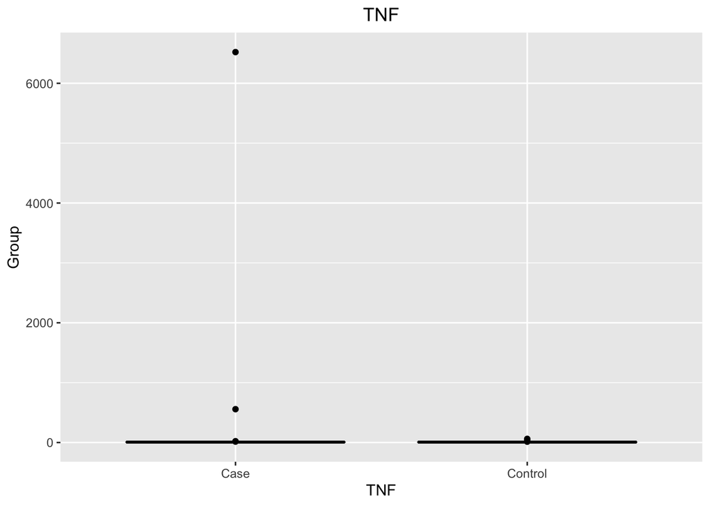

```r
ggplot(my_data1 %>% drop_na(tnf_ems, `Experimental Paradigm`), aes(y= tnf_ems, x=`Experimental Paradigm`)) +
  geom_boxplot(color='black', fill = 'white') +
  ggtitle("TNF") +
  theme(plot.title = element_text(hjust = 0.5)) +
  ylab ("Group") +
  xlab ("TNF")
```

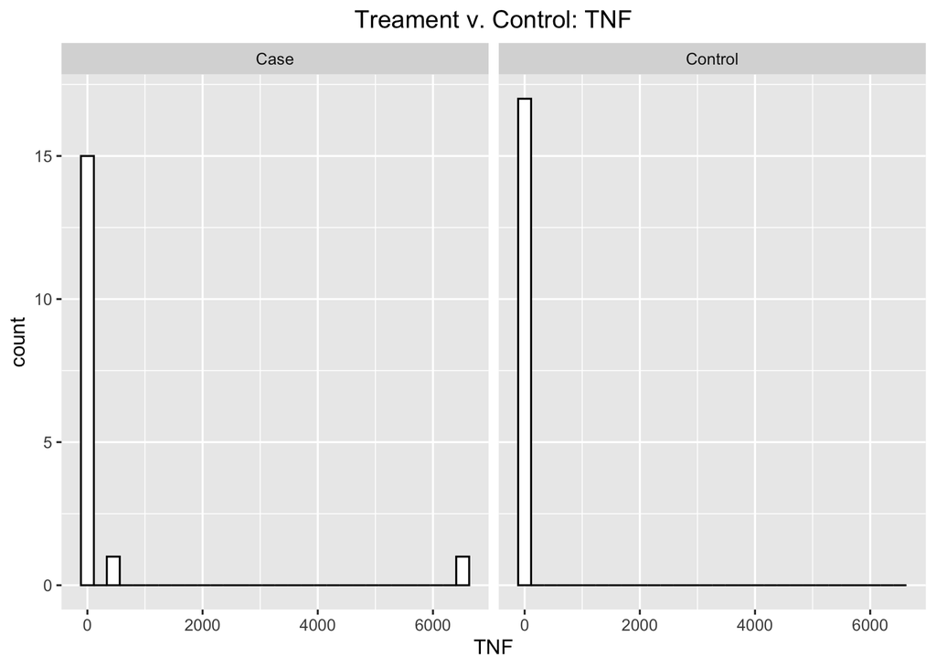

```r
ggplot(my_data1 %>% drop_na(`Experimental Paradigm`, tnf_ems), aes(x=tnf_ems)) +
  geom_histogram(color='black', fill ='white') +
  ggtitle("Treament v. Control: TNF") +
  theme(plot.title = element_text(hjust = 0.5)) +
  xlab ("TNF") +
  facet_wrap(~`Experimental Paradigm`)
```

Right-skewed, so will use a Wilcoxon signed-rank.

```r
wilcox.test(my_data_final$TNF_case, my_data_final$TNF_control, paired=TRUE, correct=FALSE)
```

```
    Wilcoxon signed rank test

data:  my_data_final$TNF_case and my_data_final$TNF_control
V = 58, p-value = 0.9096
alternative hypothesis: true location shift is not equal to 0
```

### 4.1.4 Hospital Outcomes

#### 4.1.4.1 Hospital LOS

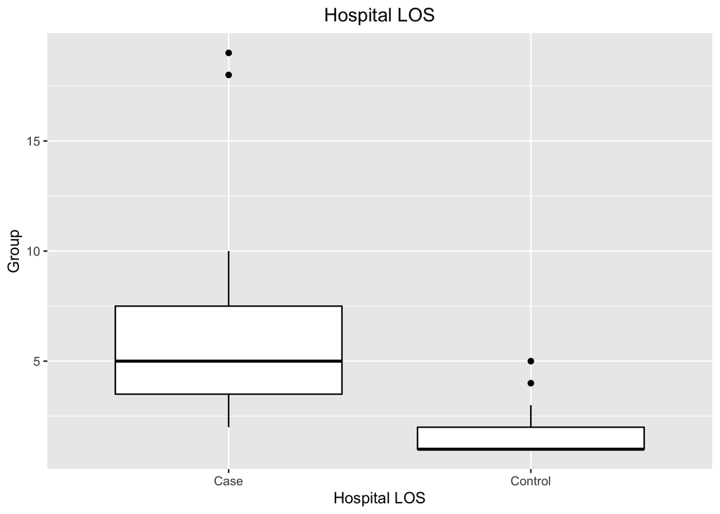

```r
ggplot(my_data1 %>% drop_na(Hosp_los, `Experimental Paradigm`), aes(y= Hosp_los, x=`Experimental Paradigm`)) +
  geom_boxplot(color='black', fill = 'white') +
  ggtitle("Hospital LOS") +
  theme(plot.title = element_text(hjust = 0.5)) +
  ylab ("Group") +
  xlab ("Hospital LOS")
```

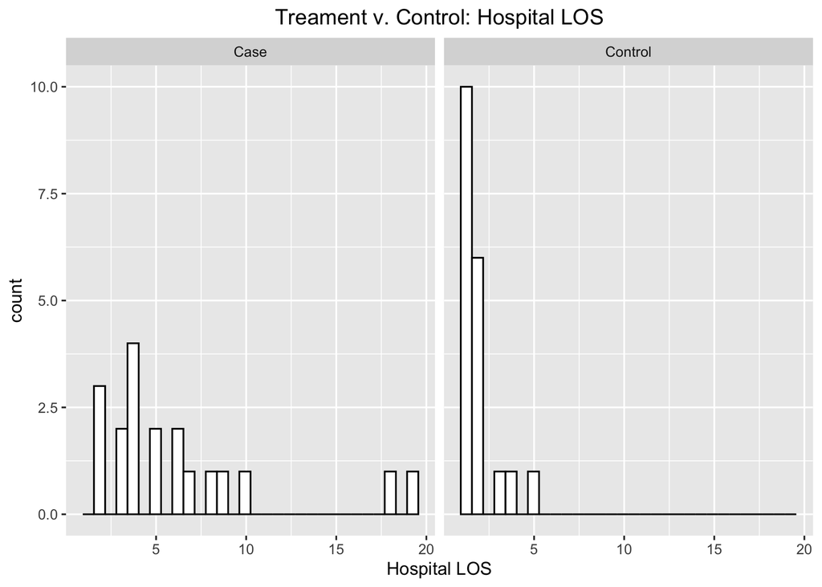

```r
ggplot(my_data1 %>% drop_na(`Experimental Paradigm`, Hosp_los), aes(x=Hosp_los)) +
  geom_histogram(color='black', fill ='white') +
  ggtitle("Treament v. Control: Hospital LOS") +
  theme(plot.title = element_text(hjust = 0.5)) +
  xlab ("Hospital LOS") +
  facet_wrap(~`Experimental Paradigm`)
```

Right-skewed, so will use a Wilcoxon signed-rank.

```r
wilcox.test(my_data_final$HospLOS_case, my_data_final$HospLOS_control, paired=TRUE, correct=FALSE)
```

```
    Wilcoxon signed rank test

data:  my_data_final$HospLOS_case and my_data_final$HospLOS_control
V = 136, p-value = 0.0004282
alternative hypothesis: true location shift is not equal to 0
```

#### 4.1.4.2 ICU

```r
table(my_data1$`Experimental Paradigm`,my_data1$ICU)
```

```
          No Yes
  Case    15   4
  Control 19   0
```

```r
m <- matrix(c(15, 19, 4, 0), nrow = 2)
fisher.test(m)
```

```
    Fisher's Exact Test for Count Data

data:  m
p-value = 0.105
alternative hypothesis: true odds ratio is not equal to 1
95 percent confidence interval:
 0.000000 1.410552
sample estimates:
odds ratio
         0
```

#### 4.1.4.3 Dead

```r
table(my_data1$`Experimental Paradigm`,my_data1$Dead)
```

```
          No Yes
  Case    17   2
  Control 19   0
```

```r
m <- matrix(c(17, 19, 2, 0), nrow = 2)
fisher.test(m)
```

```
    Fisher's Exact Test for Count Data

data:  m
p-value = 0.4865
alternative hypothesis: true odds ratio is not equal to 1
95 percent confidence interval:
 0.000000 5.278031
sample estimates:
odds ratio
         0
```